# Detection and Reporting Model of Global Speceis First Record Database

Muchen Wang

2024-05-03

# Detection and Reporting Model of Global Species First Record Database

## Introduction

The ability to detect and report invasive species accurately and promptly is critical in managing biodiversity and preventing the adverse effects of invasions. The detection and reporting model outlined here is designed to estimate the number of new invasions of species detected and reported over time, incorporating the probabilities associated with detection delays and reporting lags. This model is particularly valuable for ecological researchers and policymakers who need to understand the dynamics of species invasions and their impacts on ecosystems.

## Formula Description

The formula for estimating the number of new invasions detected in a particular year ($T_d$) and reported by a subsequent year ($T_r$) is given by:

$$F(T_d) = \sum_{T_i = t_0}^{T_d} \left(
I(T_i) \cdot \left( \prod_{j=0}^{T_d-T_i-1} (1-P_d(j)) \right) \cdot
P_d(T_d-T_i) \cdot \left(1- \prod_{m=0}^{T_r-T_d} (1- P_r(m)) \right)
\right)$$

### Process

- **Initial Invasion**: Accounting for invasions starting from year $T_i$.
- **Non-Detection Period**: The period from the year of invasion up to just before detection.
- **Detection Year**: The specific year where detection occurs.
- **Reporting Delay**: The delay from detection to reporting.

## Initialization

```r
rm(list=ls());gc()
```

```
##          used (Mb) gc trigger (Mb) max used (Mb)
## Ncells 511470 27.4    1139220 60.9   644245 34.5
## Vcells 904201  6.9    8388608 64.0  1634948 12.5
```

```r
#graphics.off()
library(ggplot2)
library(dplyr)
library(tidyr)
library(gridExtra)
library(foreach)
library(doParallel)

params = FALSE
simulate = FALSE
fit = FALSE
prediction = FALSE
plot_params = TRUE
plot_curves = TRUE
```

## Functions

This section defines key functions used in the simulation model, each tailored to simulate specific aspects of the invasion, detection, and reporting processes.

### Invasion Growth Function

The `invasion_growth` function models the logistic growth of species invasions.

- **Parameters**:
  - `t`: A given year.
  - `K`: Carrying capacity, the maximum population size that the environment can sustain.
  - `r`: Rate of increase, defining how quickly the population approaches its carrying capacity.
  - `t_m`: The year in which the population reaches half of the carrying capacity, marking the inflection point of the logistic curve.
  - `r_d` (currently ignored): Rate of decline post-peak invasion.
  - `t_d` (currently ignored): The year in which the decline begins.

### Sigmoid Function

The `sigmoid_function` simulates the logistic increase in the probability of detection or reporting as the abundance of the species increases.

- **Parameters**:
  - `t`: A given year.
  - `yoi`: Year of the invasion.
  - `beta`: Shapes the logistic curve, affecting how the probability changes over time.
  - `rate`: Rate of increase, determining how quickly the probability approaches 1.
  - `p0`: A starting value, setting the initial probability before any increase.

### Calculate Fb Function

The `calculate_Fb` function estimates the number of species detected in year `a` and reported by year `b`.

- **Parameters**:
  - `t0`: Starting year of the simulation.
  - `a`: Year of detection.
  - `b`: Year of reporting (version of the database).
  - `I`: Array of actual invasions from year `t0` to year `b`.
  - `pd_beta`, `r_pd`, `pd0`: Parameters determining the probability of detection.
  - `pr_beta`, `r_pr`, `pr0`: Parameters determining the probability of reporting.

```r
#Assume the growth of invasion is logistic
invasion_growth <- function(t, K, r, t_m, r_d, t_d) {
  K / (1 + exp((-r) * (t - t_m)))
}

#Simulate that the probability of detection increases logistically due to abundance
sigmoid_function <- function(t, yoi, beta, rate, p0) {
  if ( beta == 0 && rate == 0 && p0 == 0){
    return(1)
  }else{
    return(1-exp(-rate * (t - yoi)^beta - p0))
  }
}

#Apply formula to calculate #sp detected in Td and reported by Tr

calculate_Fb <- function(a, I, pd_beta, r_pd, pr_beta, r_pr, pd0, pr0, t0, b) {
  Fb <- 0
  for (i in t0:a) {
    pd_product <- if (i < a) {
      prod(1 - sapply(i:(a-1), sigmoid_function, i, pd_beta, r_pd, pd0))
    } else {
      1
    }
    pd_current <- sigmoid_function(a, i, pd_beta, r_pd, pd0)
    pr_product <- 1-prod(1 - sapply(a:b, sigmoid_function, a, pr_beta, r_pr, pr0))

    Fb <- Fb + I[i - t0 + 1] * pd_product * pd_current * pr_product
  }
  return(Fb)
}

# Generate I values using the logistic growth function

# Loss function definition
loss <- function(params, species_count_df) {
  params1=null_params
  params1[names(params)]=params

  K <- params1[1]
  r <- params1[2]
  t_m <- params1[3]
  r_d <- 0
  t_d <- 0
  pd_beta <- params1[4]
  r_pd <- params1[5]
  pd0 <- params1[6]
  pr_beta <- params1[7]
  r_pr <- params1[8]
  pr0 <- params1[9]

  years <- t0:b
  I <- sapply(years, invasion_growth, K, r, t_m, r_d, t_d)

  Fb_values <- sapply(years, function(a) calculate_Fb(a, I, pd_beta, r_pd, pr_beta, r_pr, pd0, pr0, t0, b))

  obs <- species_count_df$pre
  ls = sum((Fb_values - obs)^2)
  # print(params)
  # print(ls)
  if (is.na(ls) || !is.finite(ls)) {
    ls = 1e12
  }
  return(ls)
}

#Generate a dataframe that contains the years from t0 to b, predicted #sp and #actual invasions
predict = function(params, b){
  params1=null_params
  params1[names(params)]=params

  K <- params1[1]
  r <- params1[2]
  t_m <- params1[3]
  r_d <- 0
  t_d <- 0
  pd_beta <- params1[4]
  r_pd <- params1[5]
  pd0 <- params1[6]
  pr_beta <- params1[7]
  r_pr <- params1[8]
  pr0 <- params1[9]

  years <- t0:b
  I <- sapply(years, invasion_growth, K, r, t_m, r_d, t_d)
  # Calculate Fb_values
  Fb_values <- sapply(years, function(a) {
    Fb <- calculate_Fb(a, I, pd_beta, r_pd, pr_beta, r_pr, pd0, pr0, t0, b)
    return(Fb)
  })
  result = data.frame(year = years, pre = Fb_values, invasion = I)
  return(result)
}

#Plot the fitted and simulated curve from t0 to b for each simulations
plot_pre_over_year <- function(prediction_df, results_df, index) {
  # Combine the two data frames by year
  combined_df <- merge(prediction_df, results_df, by = "year", suffixes = c("_pred", "_res"))

  # Plotting
  p <- ggplot(combined_df, aes(x = year)) +
    geom_line(aes(y = pre_pred, color = "Predicted")) +
    geom_line(aes(y = pre_res, color = "Results")) +
    labs(title = paste("Parameter Set", index), y = "Pre", x = "Year") +
    scale_color_manual(values = c("Predicted" = "blue", "Results" = "red")) +
    theme_bw()

  return(p)
}

#find the outliers in the fitted parameters
identify_outliers <- function(x) {
  q1 <- quantile(x, 0.25)
  q3 <- quantile(x, 0.75)
  iqr <- q3 - q1
  lower_bound <- q1 - 1.5 * iqr
  upper_bound <- q3 + 1.5 * iqr
  x < lower_bound | x > upper_bound
}
```

## Generate Simulations

This section generate the simulation based on the parameters randomly generated within a reasonable range.

```r
set.seed(123) # Ensure reproducibility
n <- 40 # Number of random selections
t0 = 1990
b = 2020
lp = 0.75
hp = 1.25
null_params = c(K = 800, r = 2e-02, t_m = 1.800e+03, pd_beta = 0, r_pd = 0, pd0 = 0, pr_beta = 0, r_pr = 0, pr0 = 0)
if(params){
  baseline_params <- list(K = 1.000e+03,
                          r = 2e-02,
                          t_m = 1.872e+03,   # Midpoint of logistic growth
                          # r_d = 2.000e-01,
                          # t_d = 1.995e+03,
                          pd_beta = 1.599e+00,
                          r_pd = 0.000001e+00,
                          pd0 = 5.407e-03,
                          pr_beta = 1.367900e+00,
                          r_pr = 8.968628e-03,
                          pr0 = 8.048386e-03)

  #generate the different cases of simulated real world


  random_params <- replicate(n, {
    list(
      K = runif(1, 500, 1500),
      r = baseline_params$r * runif(1, lp, hp),
      t_m = runif(1, 1800, 2000),   # Midpoint of logistic growth
      # r_d = baseline_params$r_d * runif(1, lp, hp),
      # t_d = baseline_params$t_d * runif(1, lp, hp),
      pd_beta = baseline_params$pd_beta * runif(1, lp, hp),
      r_pd = baseline_params$r_pd * runif(1, lp, hp),
      pd0 = baseline_params$pd0 * runif(1, lp, hp),
      pr_beta = baseline_params$pr_beta * runif(1, lp, hp),
      r_pr = baseline_params$r_pr * runif(1, lp, hp),
      pr0 = baseline_params$pr0 * runif(1, lp, hp)
    )
  }, simplify = FALSE)
  saveRDS(random_params, paste0("../model_result/fit_simulation_params_", n, "_", t0, "_", lp*100, "-", hp*100, ".rds"))
}
random_params = readRDS(paste0("../model_result/fit_simulation_params_", n, "_", t0, "_", lp*100, "-", hp*100, ".rds"))


if (simulate){
  results_n <- mapply(function(params, i, b) {
    # Construct the name using the index i
    name <- paste("n", i, sep = "_")

    # Convert the list of parameters to a numeric vector in the correct order
    params_vector <- unlist(params)

    # Call the predict function with the parameters vector and b
    result <- predict(params_vector, b)

    # Return a named list with the result
    setNames(list(result), name)
  }, random_params, seq_along(random_params), MoreArgs = list(b = b), SIMPLIFY = FALSE)

  saveRDS(results_n, paste0("../model_result/fit_simulation_results_", n, "_", t0, "_", lp*100, "-", hp*100, ".rds"))
}

results_n = readRDS(paste0("../model_result/fit_simulation_results_", n, "_", t0, "_", lp*100, "-", hp*100, ".rds"))
```

random_params contains the combinations of parameters randomly generated to simulate the real world.

```r
random_params[[1]]
```

```
## $K
## [1] 787.5775
##
## $r
## [1] 0.02288305
##
## $t_m
## [1] 1881.795
##
## $pd_beta
## [1] 1.905222
##
## $r_pd
## [1] 1.220234e-06
##
## $pd0
## [1] 0.004178412
##
## $pr_beta
## [1] 1.387123
##
## $r_pr
## [1] 0.01072836
##
## $pr0
## [1] 0.00825537
```

results_n contains the n number of simulated results. Each simulations contains years, number of species reported and actual invasions

```r
results_n[[1]]
```

```
## $n_1
##    year        pre invasion
## 1  1990  3.0292727 726.4976
## 2  1991  6.0521160 727.7745
## 3  1992  9.0699715 729.0268
## 4  1993 12.0841363 730.2550
## 5  1994 15.0957949 731.4595
## 6  1995 18.1059700 732.6405
## 7  1996 21.1153694 733.7985
## 8  1997 24.1240285 734.9338
## 9  1998 27.1305717 736.0468
## 10 1999 30.1308139 737.1380
## 11 2000 33.1153383 738.2075
## 12 2001 36.0656705 739.2559
## 13 2002 38.9488229 740.2835
```

[output cut: 18 more lines]

## Fitting

This section examines how well the fitting process of this model is. The default method is used in optim.

```r
if (fit){
  init_params = c(K = 800, r = 2e-02, t_m = 1.800e+03, pd_beta = 1, r_pd = 1e-03, pd0 = 0.0050)
  # lower_bounds <- c(1, 0.000001, 0, 0.000001, 0,  -Inf, 0, 0, -Inf, 0, 0)
  # upper_bounds <- c(1e5, 1, 2050, 1, 2050,  Inf, Inf, Inf, Inf, Inf, Inf)
  registerDoParallel()
  options(cores=15)
  fitted_n <- foreach(i = seq_along(results_n), .combine = 'c') %dopar% {
    result <- results_n[[i]]
    name <- paste("fitted", i, sep = "_")
    species_count_df <- result[[1]]  # Ensure this is correctly extracting species_count_df
    l <- 1e10
    not_best_fit <- TRUE
    # init_params <- random_params[[i]]  # Assuming this needs to be specific for each iteration
    # opt_results <- optim(init_params, function(params) loss(params, species_count_df), control = list(maxit = 10))
    while (l > 1e-5 && not_best_fit) {
      old_init_params <- init_params
      opt_results <- optim(init_params, function(params) loss(params, species_count_df), control = list(maxit = 2000))
      # opt_results <- optim(init_params, function(params) loss(params, species_count_df), method = "CG", control = list(maxit = 20000))
      # opt_results <- optim(init_params, function(params) loss(params, species_count_df), method = "BFGS", control = list(maxit = 20000))
      # opt_results <- optim(init_params, function(params) loss(params, species_count_df), method = "SANN", control = list(maxit = 20000, temp = 15, tmax = 50))
      # opt_results <- optim(init_params, function(params) loss(params, species_count_df), control = list(maxit = 20000))
      # opt_results <- optim(init_params, function(params) loss(params, species_count_df), control = list(maxit = 2000))
      # opt_results <- optim(init_params, function(params) loss(params, species_count_df), method = "L-BFGS-B", lower = lower_bounds, upper = upper_bounds, control = list(maxit = 20000))
      # cat("new l\n")
      l <- opt_results$value
      init_params <- opt_results$par
      if (identical(old_init_params, init_params)){
        not_best_fit <- FALSE
      }
    }

    # Return named list of optimization results
    setNames(list(opt_results), name)
  }
  saveRDS(fitted_n, paste0("../model_result/fit_simulation_fitted_results_", n, "_", t0, "_", lp*100, "-", hp*100, ".rds"))
}

fitted_n = readRDS(paste0("../model_result/fit_simulation_fitted_results_", n, "_", t0, "_", lp*100, "-", hp*100, ".rds"))
```

fitted_n includes the information of the fitted parameters.

```r
fitted_n[[1]]
```

```
## $par
##            K            r          t_m      pd_beta         r_pd          pd0
## 7.367386e+02 1.658462e+03 9.075522e+02 3.946665e+00 1.601581e-07 4.164277e-03
##      pr_beta         r_pr          pr0
## 1.665244e+00 2.232711e-03 2.200780e-03
##
## $value
## [1] 0.07647253
##
## $counts
## function gradient
##      424       NA
##
## $convergence
## [1] 0
##
## $message
## NULL
```

## plot fitted params and simulated params

```r
if (plot_params){
  # Assuming random_params is a list of lists with each inner list containing parameter values
  # Convert random_params to a dataframe
  sim_params_df <- do.call(rbind, lapply(random_params, function(x) unlist(x)))

  # For fitted_n, extract optimized parameters and convert to a dataframe
  fit_params_matrix <- t(sapply(fitted_n, function(x) x$par))
  fit_params_df <- as.data.frame(fit_params_matrix)

  # Ensure column names for sim_params_df and fit_params_df match and indicate simulated vs. fitted
  # Assuming the order and number of parameters are the same for sim and fit

  colnames(sim_params_df) <- paste0("sim-", colnames(sim_params_df))
  colnames(fit_params_df) <- paste0("fit-", colnames(fit_params_df))


  # Now both dataframes should have matching column names for corresponding parameters

  # Combine the simulated and fitted parameters dataframes
  combined_params_df <- cbind(sim_params_df, fit_params_df)

  # combined_params_df <- combined_params_df %>%
  #   filter(!if_any(where(is.numeric), remove_outliers))

  # Convert the dataframe from wide to long format
  long_params_df <- pivot_longer(combined_params_df,
                                 cols = everything(),
                                 names_to = c(".value", "parameter"),
                                 names_sep = "-")
  ## add these to code if the outliers need to be excluded
  # long_params_df <- long_params_df %>%
  #   group_by(parameter) %>%
  #   mutate(outlier = identify_outliers(sim) | identify_outliers(fit)) %>%
  #   ungroup()
  #
  # long_params_df <- long_params_df %>%
  #   filter(!outlier)

  # 'long_params_df' now has a column for 'parameter' indicating the parameter name,
  # and two columns for 'sim' and 'fit' representing the simulated and fitted values.
  # Plot simulated vs. fitted values for each parameter
  p1 = ggplot(long_params_df, aes(x = fit, y = sim, color = parameter)) +
    geom_point() +  # Add points
    geom_abline(slope = 1, intercept = 0, linetype = "dashed", color = "gray") +  # Add y=x line
    facet_wrap(~ parameter, scales = "free") +  # Create a separate plot for each parameter
    theme_bw() +
    labs(x = "Fitted Value", y = "Simulated Value", title = "Simulated vs. Fitted Values for Each Parameter") +
    theme(legend.position = "none")  # Hide legend because the facet titles already indicate the parameter
  #ggsave("../model_graph/Simulated vs. Fitted Values for Each Parameter_95-10.png")
}
```

```r
  p1
```

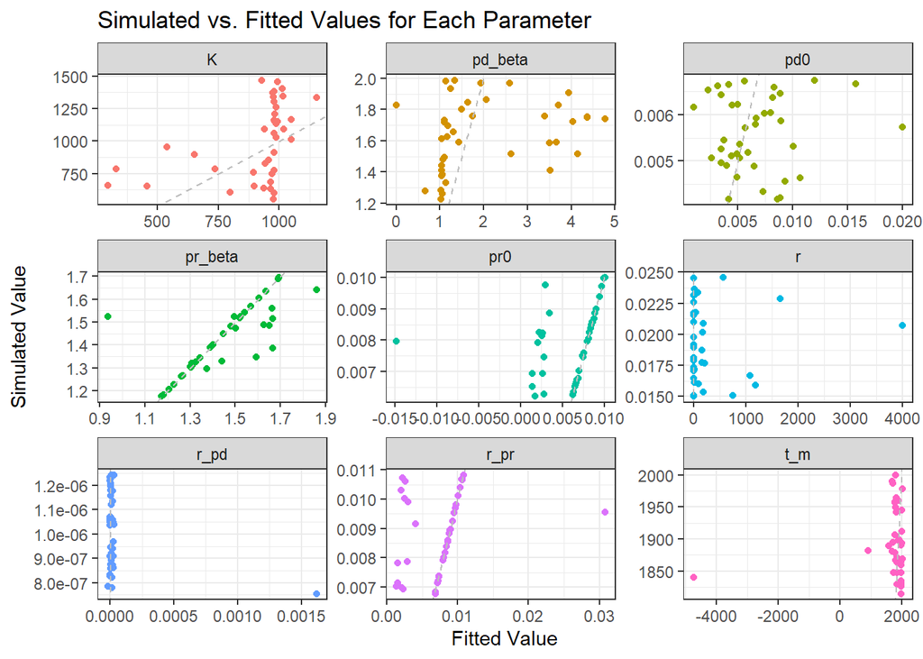

## Prediction

Based on the fitted parameters, calculate the estimated number of #sp reported in each year and compare it to the simulated results.

```r
if (prediction) {
  prediction_n <- mapply(function(params, i, b) {
    # Construct the name using the index i
    name <- paste("n", i, sep = "_")

    # Convert the list of parameters to a numeric vector in the correct order
    params_vector <- unlist(params$par)

    # Call the predict function with the parameters vector and b
    result <- predict(params_vector, b)

    # Return a named list with the result
    setNames(list(result), name)
  }, fitted_n, seq_along(fitted_n), MoreArgs = list(b = b), SIMPLIFY = FALSE)
  saveRDS(prediction_n, paste0("../model_result/fit_simulation_predicted_results_", n, "_", t0, "_", lp*100, "-", hp*100, ".rds"))
}

prediction_n = readRDS(paste0("../model_result/fit_simulation_predicted_results_", n, "_", t0, "_", lp*100, "-", hp*100, ".rds"))
```

```r
prediction_n[[1]]
```

```
## $n_1
##    year        pre invasion
## 1  1990  3.0601285 736.7386
## 2  1991  6.1049831 736.7386
## 3  1992  9.1331173 736.7386
## 4  1993 12.1443655 736.7386
## 5  1994 15.1406663 736.7386
## 6  1995 18.1262320 736.7386
## 7  1996 21.1070212 736.7386
## 8  1997 24.0894745 736.7386
## 9  1998 27.0784724 736.7386
## 10 1999 30.0744554 736.7386
## 11 2000 33.0696436 736.7386
## 12 2001 36.0433402 736.7386
## 13 2002 38.9564752 736.7386
```

[output cut: 18 more lines]

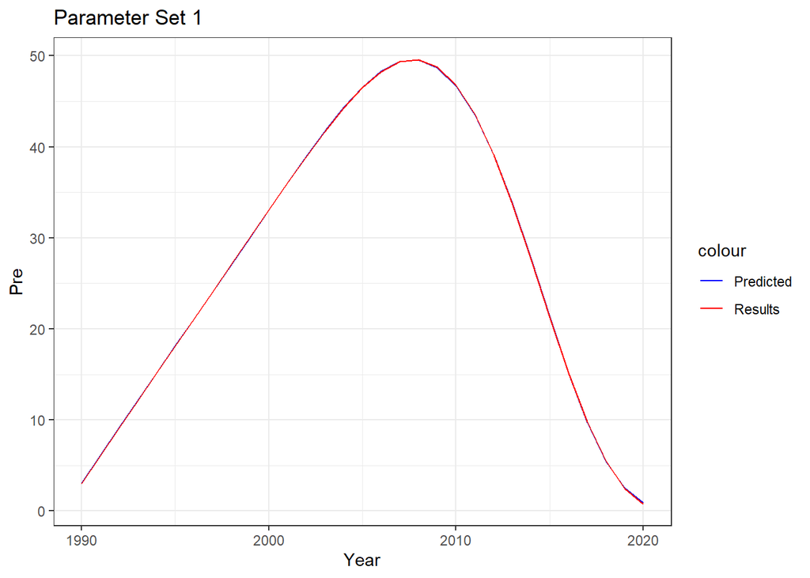

```r
if (plot_curves){
  plots_list <- lapply(1:length(prediction_n), function(i) {
    prediction_df <- prediction_n[[i]][[1]]
    results_df <- results_n[[i]][[1]]
    plot_pre_over_year(prediction_df, results_df, i)
  })

  # If you want to display all plots in one grid (consider this might be impractical with 50 plots)
  # grid.arrange(grobs = plots_list, ncol = 5)

  # Alternatively, save each plot to a file
  for (i in seq_along(plots_list)) {
    ggsave(paste0("../model_graph/simulation_", n, "_", t0, "_", lp*100, "-", hp*100, "/plot_", i, ".png", sep = ""), plots_list[[i]], width = 10, height = 6)
  }
}

plots_list[1]
```